# 00 Introduction slides

## Python is a programming language that is used for both development and analytics.

### Recently is has been the go-to language of choice for most data scientists who aim to productionalize ML models.

#### For us we'll be using Python to explore data and perform certain analytical methods to be able to derive more insight from data.

## 01 Define the Business Problem

### Say our client is a telco company, and their goal is prevent customer churn (leaving).

#### They give us data on their current/previous customers, their details, previous subscriptions and whether or not they churned.

```python
#download data from this github repository
telco = pd.read_csv('https://raw.githubusercontent.com/magtanggol03/dec130/master/datasets/telco-churn/train.csv')

#display the first three lines
telco.head(2)
```

|  | customerID | gender | SeniorCitizen | Partner | Dependents | tenure | PhoneService | MultipleLines | InternetService | OnlineSecurity | OnlineBackup | DeviceProtection | TechSupport | StreamingTV | StreamingMovies | Contract | PaperlessBilling | PaymentMethod | MonthlyCharges | TotalCharges | Churn |
| --- | --- | --- | --- | --- | --- | --- | --- | --- | --- | --- | --- | --- | --- | --- | --- | --- | --- | --- | --- | --- | --- |
| 0 | 7590-VHVEG | Female | 0 | Yes | No | 1 | No | No phone service | DSL | No | Yes | No | No | No | No | Month-to-month | Yes | Electronic check | 29.85 | 29.85 | No |
| 1 | 5575-GNVDE | Male | 0 | No | No | 34 | Yes | No | DSL | Yes | No | Yes | No | No | No | One year | No | Mailed check | 56.95 | 1889.5 | No |

## 02 How does the data help us address the problem?

### Given this data, what business problem can we help our customer solve?

### What are the hypotheses that we can make from?

```python
print('There are', telco.shape[0], 'rows and', telco.shape[1], 'columns')
```

[output not shown]

```python
print(telco.info())
```

[output not shown]

## 03 Audit the Data

### Does the data make sense? How can I further refine my hypothesis?

```python
telco.describe(include='all')
```

|  | customerID | gender | SeniorCitizen | Partner | Dependents | tenure | PhoneService | MultipleLines | InternetService | OnlineSecurity | OnlineBackup | DeviceProtection | TechSupport | StreamingTV | StreamingMovies | Contract | PaperlessBilling | PaymentMethod | MonthlyCharges | TotalCharges | Churn |
| --- | --- | --- | --- | --- | --- | --- | --- | --- | --- | --- | --- | --- | --- | --- | --- | --- | --- | --- | --- | --- | --- |
| count | 6543 | 6543 | 6543.000000 | 6543 | 6543 | 6543.000000 | 6543 | 6543 | 6543 | 6543 | 6543 | 6543 | 6543 | 6543 | 6543 | 6543 | 6543 | 6543 | 6543.000000 | 6534.000000 | 6543 |
| unique | 6543 | 2 | NaN | 2 | 2 | NaN | 2 | 3 | 3 | 3 | 3 | 3 | 3 | 3 | 3 | 3 | 2 | 4 | NaN | NaN | 2 |
| top | 2792-LSHWX | Male | NaN | No | No | NaN | Yes | No | Fiber optic | No | No | No | No | No | No | Month-to-month | Yes | Electronic check | NaN | NaN | No |
| freq | 1 | 3315 | NaN | 3381 | 4587 | NaN | 5919 | 3159 | 2877 | 3233 | 2877 | 2867 | 3230 | 2615 | 2575 | 3600 | 3858 | 2199 | NaN | NaN | 4811 |
| mean | NaN | NaN | 0.162311 | NaN | NaN | 32.356564 | NaN | NaN | NaN | NaN | NaN | NaN | NaN | NaN | NaN | NaN | NaN | NaN | 64.718890 | 2281.567210 | NaN |
| std | NaN | NaN | 0.368764 | NaN | NaN | 24.582292 | NaN | NaN | NaN | NaN | NaN | NaN | NaN | NaN | NaN | NaN | NaN | NaN | 30.126511 | 2268.964061 | NaN |
| min | NaN | NaN | 0.000000 | NaN | NaN | 0.000000 | NaN | NaN | NaN | NaN | NaN | NaN | NaN | NaN | NaN | NaN | NaN | NaN | 18.250000 | 18.800000 | NaN |
| 25% | NaN | NaN | 0.000000 | NaN | NaN | 9.000000 | NaN | NaN | NaN | NaN | NaN | NaN | NaN | NaN | NaN | NaN | NaN | NaN | 35.400000 | 397.387500 | NaN |
| 50% | NaN | NaN | 0.000000 | NaN | NaN | 29.000000 | NaN | NaN | NaN | NaN | NaN | NaN | NaN | NaN | NaN | NaN | NaN | NaN | 70.350000 | 1396.575000 | NaN |
| 75% | NaN | NaN | 0.000000 | NaN | NaN | 55.000000 | NaN | NaN | NaN | NaN | NaN | NaN | NaN | NaN | NaN | NaN | NaN | NaN | 89.850000 | 3778.687500 | NaN |
| max | NaN | NaN | 1.000000 | NaN | NaN | 72.000000 | NaN | NaN | NaN | NaN | NaN | NaN | NaN | NaN | NaN | NaN | NaN | NaN | 118.750000 | 8684.800000 | NaN |

```python
def getDist(cols):
    fig, ax = plt.subplots(2, 5, figsize = (20,10))
    idx = 0

    for col in cols:
        temp_df = telco[col]

        if temp_df.dtype == np.int64 or temp_df.dtype == np.float64:
            temp_df.hist(ax = ax[int(idx/5), idx%5])
        else:
            pd.DataFrame(temp_df.value_counts()).plot(kind = 'bar', ax = ax[int(idx/5), idx%5])
        ax[int(idx/5), idx%5].title.set_text(col)
        idx += 1

    plt.tight_layout()
```

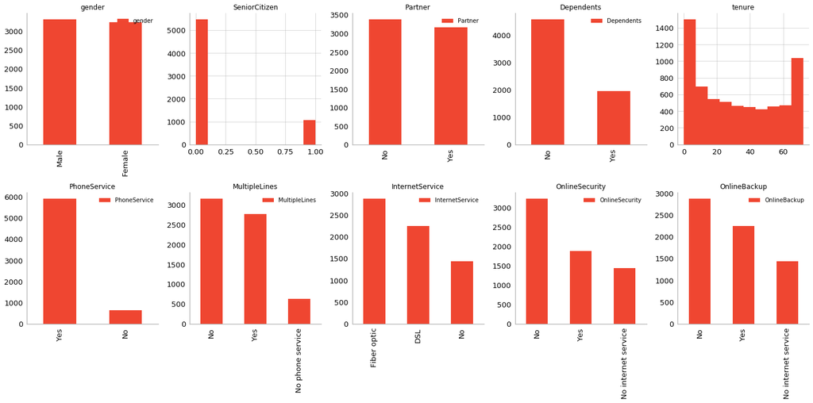

```python
#Get the distribution of the different values of each feature/variable
getDist(telco.columns[1:11])
```

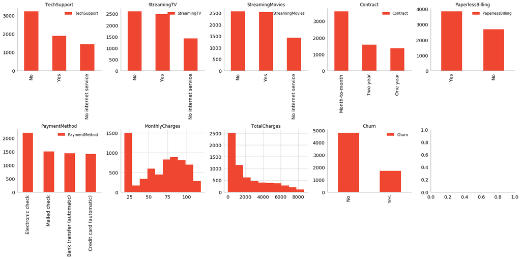

```python
#Get the distribution of the different values of each feature/variable
getDist(telco.columns[12:])
```

## 04 Test Your Hypothesis

### Figure out what models or experiments to run to validate or invalidate your thoughts

### We can view some features relative to our dependent variable, Churn.

#### For example in the chart below, we can see that there is no significant difference in the distribution of gender for the population of customer who churned and didn't churn.

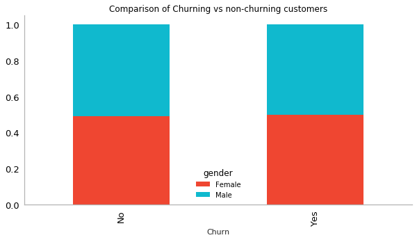

```python
compWchurn('gender')
```

### Gender probably will not be an important factor in predicting customer churn.

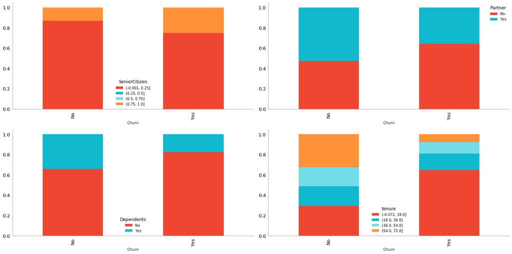

```python
fig,ax = plt.subplots(2, 2, figsize = (20,10))

compWchurn('SeniorCitizen', ax[0,0])
compWchurn('Partner', ax[0,1])
compWchurn('Dependents', ax[1,0])
compWchurn('tenure', ax[1,1])
plt.tight_layout()
```

## HOMEWORK

Download the testing set of this data at https://raw.githubusercontent.com/magtanggol03/dec130/master/datasets/telco-churn/test.csv

```python
#download data from this github repository
telco = pd.read_csv('https://raw.githubusercontent.com/magtanggol03/dec130/master/datasets/telco-churn/test.csv')

#display the first three lines
telco.head(2)
```

|  | customerID | gender | SeniorCitizen | Partner | Dependents | tenure | PhoneService | MultipleLines | InternetService | OnlineSecurity | OnlineBackup | DeviceProtection | TechSupport | StreamingTV | StreamingMovies | Contract | PaperlessBilling | PaymentMethod | MonthlyCharges | TotalCharges |
| --- | --- | --- | --- | --- | --- | --- | --- | --- | --- | --- | --- | --- | --- | --- | --- | --- | --- | --- | --- | --- |
| 0 | 8050-XGRVL | Female | 0 | Yes | Yes | 62 | Yes | No | DSL | Yes | No | Yes | No | No | No | One year | No | Credit card (automatic) | 54.75 | 3425.35 |
| 1 | 6661-HBGWL | Female | 1 | No | No | 42 | Yes | Yes | Fiber optic | No | Yes | Yes | No | Yes | Yes | Month-to-month | Yes | Bank transfer (automatic) | 104.75 | 4323.45 |

This contains 500 customers with all the same data, except the Churning data. By next week, submit the dataset with your predictions on whether or not each customer will Churn or not. No need to use Python (feel free to use excel or your own personal judgement).

Then submit your predictions on an excel file with ONLY TWO COLUMNS, customerID and Churn (your prediction) and a ONE PAGE PAPER MAX on the thought behind your predictions.

Submit here: https://drive.google.com/drive/folders/1opyNiGcaW7r1-KyuK286kWqdnB7Kul4q